```r
library(ggplot2)
```

## Loading and preprocessing the data

```r
setwd("G:/Data Science/5. Reproducible Research/Week2")
data <- read.table(file = "activity.csv", header = TRUE, sep=",")
head(data)
```

```
##   steps       date interval
## 1    NA 2012-10-01        0
## 2    NA 2012-10-01        5
## 3    NA 2012-10-01       10
## 4    NA 2012-10-01       15
## 5    NA 2012-10-01       20
## 6    NA 2012-10-01       25
```

## What is mean total number of steps taken per day?

1. Calculate the total number of steps taken per day

```r
totalstepsperday <- aggregate(steps~date, data, sum)
totalstepsperday
```

```
##          date steps
## 1  2012-10-02   126
## 2  2012-10-03 11352
## 3  2012-10-04 12116
## 4  2012-10-05 13294
## 5  2012-10-06 15420
## 6  2012-10-07 11015
## 7  2012-10-09 12811
## 8  2012-10-10  9900
## 9  2012-10-11 10304
## 10 2012-10-12 17382
## 11 2012-10-13 12426
## 12 2012-10-14 15098
## 13 2012-10-15 10139
## 14 2012-10-16 15084
```

[output cut: 39 more lines]

2. If you do not understand the difference between a histogram and a barplot, research the difference between them. Make a histogram of the total number of steps taken each day.

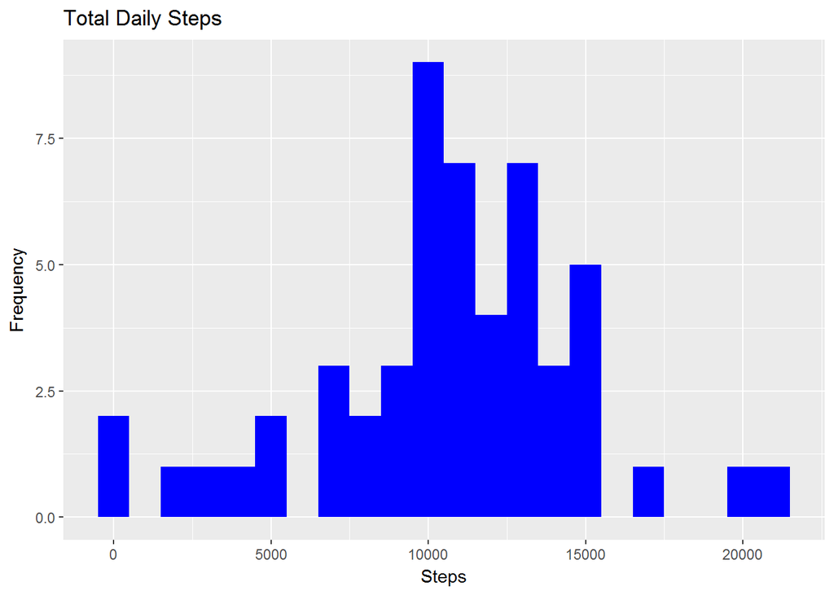

```r
ggplot(totalstepsperday, aes(steps)) + geom_histogram(fill = 4, binwidth = 1000) + labs(title = "Total Daily Steps", x = "Steps", y = "Frequency")
```

```r
meansteps <- mean(totalstepsperday$steps, na.rm=TRUE)
mediansteps <- median(totalstepsperday$steps, na.rm=TRUE)
```

## What is the average daily activity pattern?

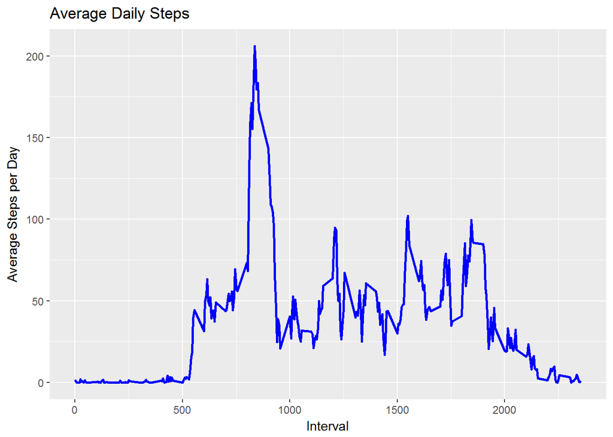

```r
averagestepsperday <- aggregate(steps~interval, data, mean)
ggplot(averagestepsperday, aes(interval, steps)) + geom_line(col = 4, lwd=1) + labs(title = "Average Daily Steps", x = "Interval", y = "Average Steps per Day")
```

2. Which 5-minute interval, on average across all the days in the dataset, contains the maximum number of steps?

```r
averagestepsperday[averagestepsperday$steps == max(averagestepsperday$steps),]
```

```
##     interval    steps
## 104      835 206.1698
```

## Imputing missing values

```r
missingvalues <- sum(is.na(data$steps))
```

The total number of missing values are 2304

2. Devise a strategy for filling in all of the missing values in the dataset. The strategy does not need to be sophisticated. For example, you could use the mean/median for that day, or the mean for that 5-minute interval, etc.

Fill in all the misiing values with the mean of steps.

3. Create a new dataset that is equal to the original dataset but with the missing data filled in.

```r
data2 <- data
data2$steps[is.na(data2$steps)] <- mean(data$steps, na.rm = TRUE)
```

4. Make a histogram of the total number of steps taken each day and calculate and report the mean and median total number of steps taken per day. Do these values differ from the estimates from the first part of the assignment? What is the impact of imputing missing data on the estimates of the total daily number of steps?

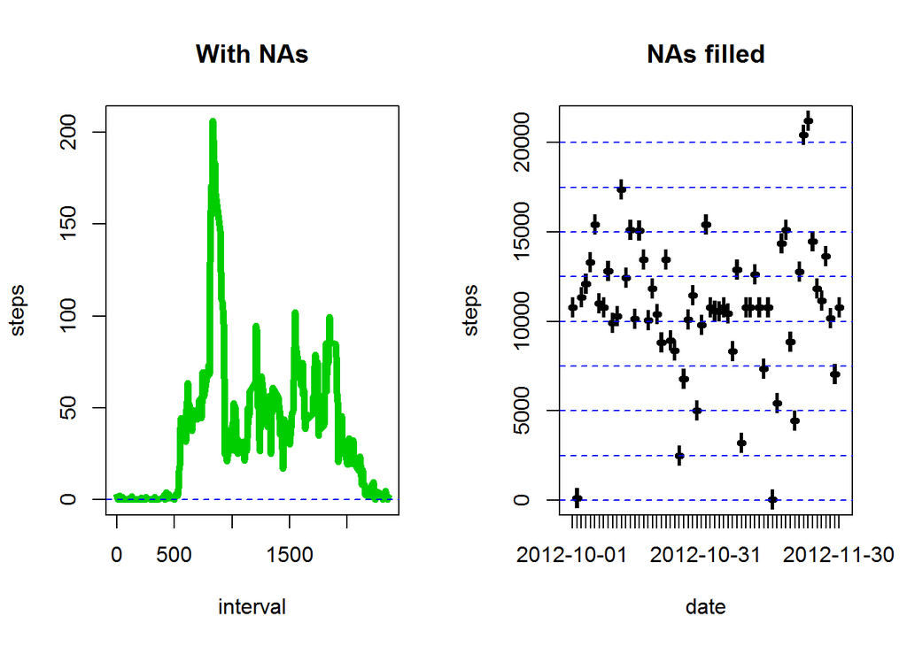

```r
averagestepsperday2 <- aggregate(steps ~ date, data2, sum, na.rm=TRUE)
par(mfrow = c(1, 2))
plot(averagestepsperday, type = "l", lwd = 5,lend = "square", main = "With NAs", col = 3)
abline(h = seq(0, 20000, 2500), lty = "dashed", col = 4)
plot(averagestepsperday2, type = "l", lwd = 5, lend = "square", main = "NAs filled", col = 3)
abline(h = seq(0, 20000, 2500), lty = "dashed", col = 4)
```

```r
mean(data2$steps)
```

```
## [1] 37.3826
```

```r
median(data2$steps)
```

```
## [1] 0
```

## Are there differences in activity patterns between weekdays and weekends?

1. Create a new factor variable in the dataset with two levels - “weekday” and “weekend” indicating whether a given date is a weekday or weekend day.

```r
data$date <- as.Date(data$date, format = "%Y-%m-%d")
data$dayname <- format(data$date, "%A")
data[grepl("Monday|Tuesday|Wednesday|Thrusday|Friday", data$dayname), "weekday_or_weekend"] <- "weekday"
data[grepl("Saturday|Sunday", data$dayname), "weekday_or_weekend"] <- "weekend"
data$`weekday_or_weekend` <- factor(data$`weekday_or_weekend`)
```

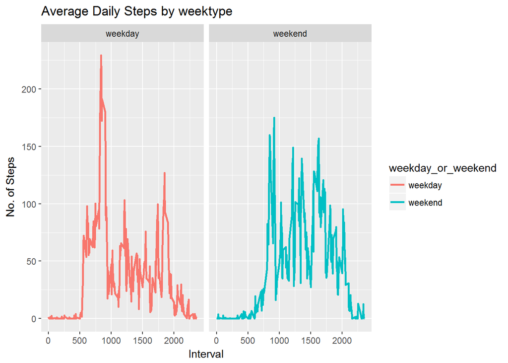

```r
avgsteps <- aggregate(steps ~ interval + weekday_or_weekend, data, mean, na.rm = TRUE)
ggplot(avgsteps, aes(interval, steps)) + geom_line(aes(color = weekday_or_weekend), lwd = 1) + facet_wrap(~weekday_or_weekend) + labs(title = "Average Daily Steps by weektype",y= "No. of Steps", x = "Interval")
```